# Liste Rouge Régionale des poissons d’eau douce de Bretagne

## 3.2 Temps de génération des espèces évaluées

Les critères de classification de l’UICN nécessitent l’utilisation d’un temps de génération spécifique à chacun des taxons étudiés. La durée d’une génération correspond à l’âge moyen des parents de la cohorte actuelle, c’est-à-dire des parents des nouveau-nés dans la population (UICN, 2012). D’après l’UICN (2012), le risque de disparition « à court terme » d’une espèce fait référence à une période de dix ans ou à trois générations pour les espèces dont la durée de trois générations dépasse les dix ans. L’utilisation de cette période de référence comme standard méthodologique permet d’assurer une comparaison jugée comme « sereine » entre échelles ou territoires (Vigneron et al., 2017). Les temps de génération des espèces étudiées ainsi que leur temps d’étude pour ce travail sont établi dans la colone *periode_etude_lrr* pour chaque espèce évaluée à partir des temps de générations :

```r
reg_espece <- reg_espece %>%
  filter(statut_lrr == "Applicable")

reg_espece <- reg_espece %>%
  mutate(periode_etude_lrr = ifelse(3 * temps_generation >= 10, 3 * temps_generation, 10)) %>%
  mutate(annee_debut = 2023 - periode_etude_lrr) %>%
  mutate(periode_etude = paste(annee_debut, "2023", sep = "-"))
```

```r
tab_reg_espece <- dplyr::select(reg_espece,
                                esp_nom_commun,
                                esp_code_alternatif,
                                temps_generation,
                                periode_etude_lrr,
                                periode_etude)

colnames(tab_reg_espece) <- c("Nom commun", "Nom de code", "Temps de génération","Durée d'étude LRR","Période d'étude LRR")

tab_reg_espece %>%
  flextable::flextable() %>%
  flextable::autofit() %>%
  flextable::colformat_int(j = c(1, 3), big.mark = " ")
```

| Nom commun | Nom de code | Temps de génération | Durée d'étude LRR | Période d'étude LRR |
| --- | --- | --- | --- | --- |
| Anguille européenne | ANG | 11 | 33 | 1990-2023 |
| Brochet | BRO | 5 | 15 | 2008-2023 |
| Chabot | CHA | 3 | 10 | 2013-2023 |
| Chevesne | CHE | 6 | 18 | 2005-2023 |
| Gardon | GAR | 4 | 12 | 2011-2023 |
| Goujon | GOU | 3 | 10 | 2013-2023 |
| Loche franche | LOF | 5 | 15 | 2008-2023 |
| Lamproie de Planer | LPP | 6 | 18 | 2005-2023 |
| Perche | PER | 4 | 12 | 2011-2023 |
| Saumon atlantique | SAT | 3 | 10 | 2013-2023 |
| Truite commune | TRF | 3 | 10 | 2013-2023 |
| Vairon | VAI | 4 | 12 | 2011-2023 |
| Vandoise rostrée | VAR | 4 | 12 | 2011-2023 |

## 3.3 Occurrences des espèces par station

### 3.3.1 Mise en forme des données

Création d’un dataframe avec toutes les combinaisons possibles d’années, indicateurs, stades et esp_code_alternatif, à l’échelle régionale :

```r
combinaisons_esp_sta <- expand.grid(annee = unique(reg_indicateur$annee),
                            indicateur = unique(reg_indicateur$indicateur),
                            stade = unique(reg_indicateur$stade),
                            esp_code_alternatif = unique(reg_indicateur$esp_code_alternatif))
```

```r
# Fusionner le tableau des combinaisons avec le tableau original en ajoutant des valeurs manquantes avec valeur 0
reg_indicateur_complet <- combinaisons_esp_sta %>%
  left_join(reg_indicateur, by = c("annee", "indicateur", "stade", "esp_code_alternatif")) %>%
  mutate(valeur = ifelse(is.na(valeur), 0, valeur))
```

Création d’un dataframe avec toutes les combinaisons possibles d’années, indicateurs, stades et esp_code_alternatif, à l’échelles des opérations :

```r
combinaisons_esp_ope <- expand.grid(annee = unique(ope_indicateur$annee),
                            indicateur = unique(ope_indicateur$indicateur),
                            stade = unique(ope_indicateur$stade),
                            esp_code_alternatif = unique(ope_indicateur$esp_code_alternatif),
                            pop_id = unique(ope_indicateur$pop_id))
```

```r
# Fusionner le tableau des combinaisons avec le tableau original en ajoutant des valeurs manquantes avec valeur 0
ope_indicateur_complet <- combinaisons_esp_ope %>%
  left_join(ope_indicateur, by = c("annee", "indicateur", "stade", "esp_code_alternatif", "pop_id"))%>%
  mutate(valeur = ifelse(is.na(valeur), 0, valeur))
```

```r
# Construction d'un df avec espèce applicable et leurs temps de génération
reg_periode_etude_lrr <- reg_espece %>%
  select(esp_code_alternatif,
                  periode_etude_lrr)

ope_periode_etude_lrr <- reg_espece %>%
    select(esp_code_alternatif,
                  periode_etude_lrr)


# Maintenant, ope_indicateur_complet contient toutes les combinaisons possibles avec des valeurs de 0 pour celles qui étaient manquantes dans ope_indicateur
ope_indicateur_complet <- ope_indicateur_complet %>%
  left_join(ope_periode_etude_lrr, by = "esp_code_alternatif") %>%
  filter(esp_code_alternatif %in% mes_especes)

ope_indicateur_complet_effectif <- ope_indicateur_complet %>%
  filter(indicateur == "effectif_total",
         stade == "ind")


reg_indicateur_complet <- reg_indicateur_complet %>%
  left_join(reg_periode_etude_lrr, by = "esp_code_alternatif") %>%
  filter(esp_code_alternatif %in% mes_especes)

reg_indicateur_complet_effectif <- reg_indicateur_complet %>%
  filter(indicateur == "effectif_total",
         stade == "ind")
```

### 3.3.2 Observation des occurrences par station

On observe plus en détail l’allure de l’occurrence des espèces par station :

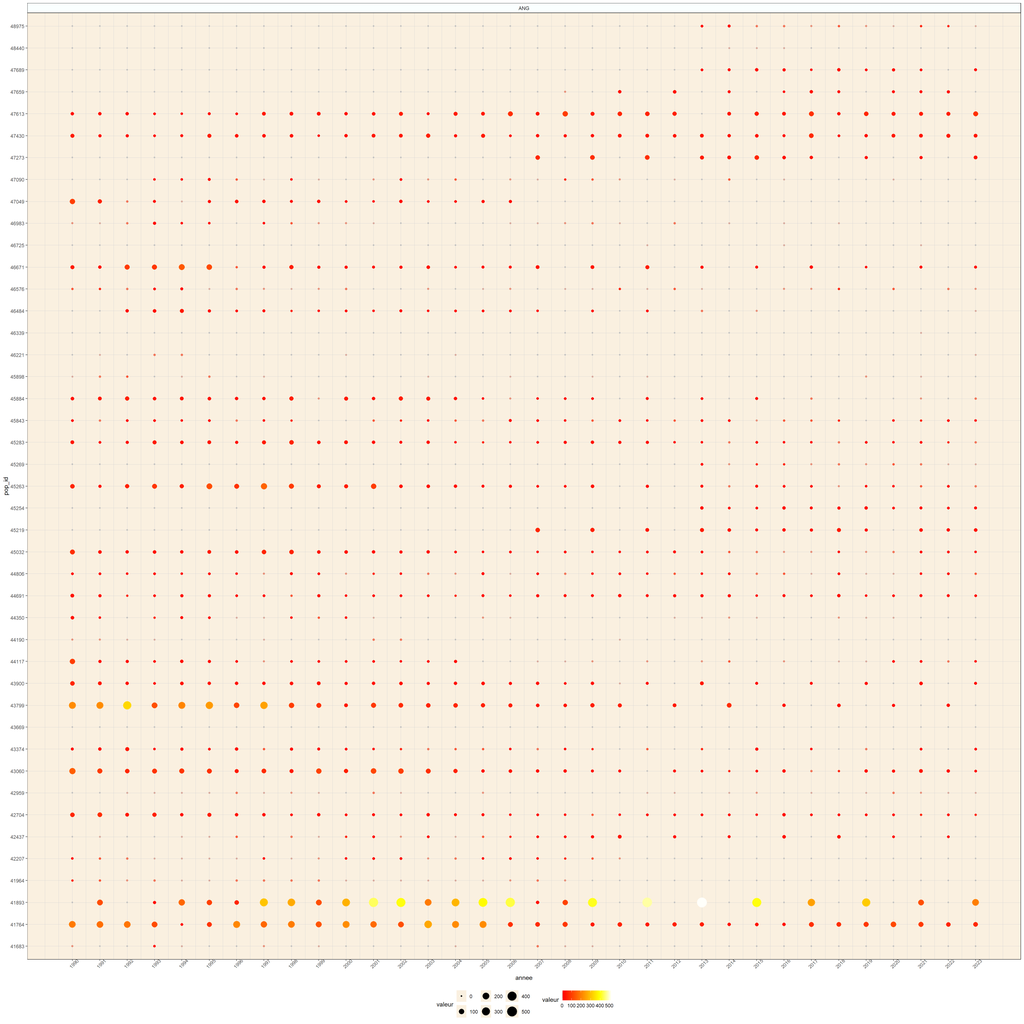

```r
occur_sta_esp <- ope_indicateur_complet_effectif %>%
  filter(stade == "ind",
         esp_code_alternatif == "ANG") %>%
  group_by(pop_id, annee, esp_code_alternatif)

# Convertir pop_id en facteur
occur_sta_esp$pop_id <- factor(occur_sta_esp$pop_id)

# Créer le graphique avec ggplot2 et facettes pour chaque espèce
ggplot(occur_sta_esp, aes(x = annee, y = pop_id, size = valeur, color = valeur)) +
  geom_point() +
  scale_size_continuous(range = c(1, 8)) + # Ajuster la plage de taille des points selon vos préférences
  scale_color_gradientn(colors = c("grey", heat.colors(99)), na.value = "grey") + # Utiliser une palette de couleurs personnalisée
  scale_x_continuous(breaks = seq(min(occur_sta_esp$annee), max(occur_sta_esp$annee), by = 1)) +
  facet_wrap(~ esp_code_alternatif, scales = "free") +
  theme_bw() +
  theme(strip.background = element_rect(color = "black", fill = "#faffff"),
        legend.position = "bottom",
        panel.background = element_rect(fill = "#faf0e0"),
        panel.grid.major = element_line(color = "lightgrey", size = 0.1),
        panel.grid.minor = element_line(color = "lightgrey"),
        axis.text.x = element_text(angle = 45))
```

# 4 Sauvegarde

```r
save(ope_indicateur,
     reg_espece,
     ope_indicateur_complet,
     reg_indicateur_complet,
     file = "../processed_data/pre_traitement_criteres_lrr_uicn.rda")
```